# Heart failure data analysis in R

Jyotishka Datta

March 28, 2019

# 1 Background

## 1.1 Data reading

```r
rm(list=ls())
setwd("C:/Users/jd033/OneDrive/Documents/R/Nursing")
heart <- read.csv("Heart-failure-project-data.csv",sep=",",header=T)
str(heart)
```

```
'data.frame':   1350 obs. of  5 variables:
 $ ï..Patient.ID: int  1 1 1 1 1 1 1 1 1 1 ...
 $ Question     : Factor w/ 25 levels "Act on Sx","Activity",..: 25 25 22 22 21 21 2 2 3 3 ...
 $ Score        : int  1 3 4 4 4 4 3 3 4 4 ...
 $ Section      : Factor w/ 3 levels "A","B","C": 1 1 1 1 1 1 1 1 1 1 ...
 $ Group        : Factor w/ 2 levels "Post","Pre": 2 1 2 1 2 1 2 1 2 1 ...
```

Before we analyze the data in R, we need to convert the data from a long format to a wide format. We also change the name of the first column from `patient ID` to `subject`.

This is done as follows:

```r
library(tidyverse)
library(reshape2)
colnames(heart)[1] <- "subject"
heart.new <- heart[,c(1:3,5)]
heart.wide <-  dcast(heart.new, subject + Group ~ Question, sum, value.var="Score")
dim(heart.wide)
```

```
[1] 60 27
```

# 2 Basic Descriptive Statistics

## 2.1 Descriptive Statistics for the “Pre” group

```r
library(summarytools)
st_options(dfSummary.na.col = FALSE)

attach(heart.wide)
heart.wide.pre = heart.wide[Group == "Pre",]
dfSummary(heart.wide.pre[,-1], plain.ascii = FALSE, style = "grid",           graph.magnif = 0.75, valid.col = FALSE, tmp.img.dir = "/tmp")
```

### 2.1.1 Data Frame Summary

**heart.wide.pre**  
**Dimensions:** 30 x 26  
**Duplicates:** 0

| No | Variable | Stats / Values | Freqs (% of Valid) | Graph |
| --- | --- | --- | --- | --- |
| 1 | Group [factor] | 1. Post 2. Pre | 0 ( 0.0%) 30 (100.0%) |  |
| 2 | Act on Sx [integer] | Mean (sd) : 2.1 (1) min < med < max: 0 < 2 < 4 IQR (CV) : 1 (0.5) | 0 : 2 ( 6.7%) 1 : 4 (13.3%) 2 : 15 (50.0%) 3 : 7 (23.3%) 4 : 2 ( 6.7%) |  |
| 3 | Activity [integer] | Mean (sd) : 2 (0.9) min < med < max: 0 < 2 < 4 IQR (CV) : 2 (0.5) | 0 : 1 ( 3.3%) 1 : 9 (30.0%) 2 : 10 (33.3%) 3 : 9 (30.0%) 4 : 1 ( 3.3%) |  |
| 4 | Appointment [integer] | Mean (sd) : 2.9 (1.4) min < med < max: 0 < 4 < 4 IQR (CV) : 2.8 (0.5) | 0 : 1 ( 3.3%) 1 : 7 (23.3%) 2 : 3 (10.0%) 3 : 2 ( 6.7%) 4 : 17 (56.7%) |  |
| 5 | Ask for low Salt [integer] | Mean (sd) : 1.1 (0.6) min < med < max: 0 < 1 < 4 IQR (CV) : 0 (0.6) | 0 : 1 ( 3.3%) 1 : 26 (86.7%) 2 : 2 ( 6.7%) 4 : 1 ( 3.3%) |  |
| 6 | Contact NP [integer] | Mean (sd) : 1.5 (0.8) min < med < max: 0 < 1 < 3 IQR (CV) : 1 (0.5) | 0 : 1 ( 3.3%) 1 : 16 (53.3%) 2 : 9 (30.0%) 3 : 4 (13.3%) |  |
| 7 | Eval Sx [integer] | Mean (sd) : 2.1 (0.9) min < med < max: 0 < 2 < 4 IQR (CV) : 1 (0.4) | 0 : 2 ( 6.7%) 1 : 3 (10.0%) 2 : 15 (50.0%) 3 : 9 (30.0%) 4 : 1 ( 3.3%) |  |
| 8 | Eval Tx [integer] | Mean (sd) : 2.1 (1.1) min < med < max: 0 < 2 < 4 IQR (CV) : 1.8 (0.5) | 0 : 2 ( 6.7%) 1 : 6 (20.0%) 2 : 12 (40.0%) 3 : 7 (23.3%) 4 : 3 (10.0%) |  |
| 9 | Exercise [integer] | Mean (sd) : 0.1 (0.4) min < med < max: 0 < 0 < 2 IQR (CV) : 0 (4) | 0 : 28 (93.3%) 1 : 1 ( 3.3%) 2 : 1 ( 3.3%) |  |
| 10 | Exercise30 [integer] | Mean (sd) : 1.4 (1) min < med < max: 0 < 1 < 4 IQR (CV) : 1 (0.7) | 0 : 3 (10.0%) 1 : 17 (56.7%) 2 : 5 (16.7%) 3 : 4 (13.3%) 4 : 1 ( 3.3%) |  |
| 11 | Follow Tx [integer] | Mean (sd) : 2.2 (0.7) min < med < max: 0 < 2 < 4 IQR (CV) : 0.8 (0.3) | 0 : 1 ( 3.3%) 1 : 2 ( 6.7%) 2 : 19 (63.3%) 3 : 7 (23.3%) 4 : 1 ( 3.3%) |  |
| 12 | Forget Meds [integer] | Mean (sd) : 1.5 (0.9) min < med < max: 0 < 1 < 4 IQR (CV) : 1 (0.6) | 0 : 1 ( 3.3%) 1 : 18 (60.0%) 2 : 7 (23.3%) 3 : 3 (10.0%) 4 : 1 ( 3.3%) |  |
| 13 | Free fromSx [integer] | Mean (sd) : 1.9 (0.6) min < med < max: 0 < 2 < 3 IQR (CV) : 0 (0.3) | 0 : 1 ( 3.3%) 1 : 4 (13.3%) 2 : 22 (73.3%) 3 : 3 (10.0%) |  |
| 14 | Inc Med [integer] | Mean (sd) : 1.5 (1) min < med < max: 0 < 1 < 4 IQR (CV) : 1 (0.7) | 0 : 1 ( 3.3%) 1 : 20 (66.7%) 2 : 3 (10.0%) 3 : 4 (13.3%) 4 : 2 ( 6.7%) |  |
| 15 | Low Salt Diet [integer] | Mean (sd) : 2 (1.2) min < med < max: 0 < 2 < 4 IQR (CV) : 2 (0.6) | 0 : 1 ( 3.3%) 1 : 12 (40.0%) 2 : 8 (26.7%) 3 : 4 (13.3%) 4 : 5 (16.7%) |  |
| 16 | Pill box [integer] | Mean (sd) : 2.9 (1.5) min < med < max: 0 < 4 < 4 IQR (CV) : 3 (0.5) | 0 : 1 ( 3.3%) 1 : 8 (26.7%) 2 : 2 ( 6.7%) 4 : 19 (63.3%) |  |
| 17 | Rec change [integer] | Mean (sd) : 2.1 (0.9) min < med < max: 0 < 2 < 4 IQR (CV) : 1 (0.4) | 0 : 2 ( 6.7%) 1 : 4 (13.3%) 2 : 15 (50.0%) 3 : 8 (26.7%) 4 : 1 ( 3.3%) |  |
| 18 | Recognize [integer] | Mean (sd) : 0.7 (1) min < med < max: 0 < 0 < 3 IQR (CV) : 1 (1.4) | 0 : 17 (58.6%) 1 : 5 (17.2%) 2 : 5 (17.2%) 3 : 2 ( 6.9%) |  |
| 19 | Reduce H2O [integer] | Mean (sd) : 1.6 (0.9) min < med < max: 0 < 1 < 3 IQR (CV) : 1 (0.5) | 0 : 1 ( 3.3%) 1 : 16 (53.3%) 2 : 7 (23.3%) 3 : 6 (20.0%) |  |
| 20 | Reduce Na [integer] | Mean (sd) : 1.9 (1.1) min < med < max: 0 < 2 < 4 IQR (CV) : 1.8 (0.6) | 0 : 1 ( 3.3%) 1 : 12 (40.0%) 2 : 9 (30.0%) 3 : 4 (13.3%) 4 : 4 (13.3%) |  |
| 21 | Remedy Eval [integer] | Mean (sd) : 0.5 (0.9) min < med < max: 0 < 0 < 3 IQR (CV) : 1 (1.7) | 0 : 21 (70.0%) 1 : 4 (13.3%) 2 : 4 (13.3%) 3 : 1 ( 3.3%) |  |
| 22 | Sick [integer] | Mean (sd) : 2.5 (1.3) min < med < max: 0 < 2.5 < 4 IQR (CV) : 2.8 (0.5) | 0 : 1 ( 3.3%) 1 : 7 (23.3%) 2 : 7 (23.3%) 3 : 6 (20.0%) 4 : 9 (30.0%) |  |
| 23 | Swelling [integer] | Mean (sd) : 2.8 (1.3) min < med < max: 0 < 3.5 < 4 IQR (CV) : 2 (0.5) | 0 : 1 ( 3.3%) 1 : 4 (13.3%) 2 : 9 (30.0%) 3 : 1 ( 3.3%) 4 : 15 (50.0%) |  |
| 24 | Symptoms [integer] | Mean (sd) : 0.9 (0.7) min < med < max: 0 < 1 < 4 IQR (CV) : 0 (0.8) | 0 : 6 (20.0%) 1 : 23 (76.7%) 4 : 1 ( 3.3%) |  |
| 25 | Tx Helped [integer] | Mean (sd) : 0.5 (0.9) min < med < max: 0 < 0 < 2 IQR (CV) : 0.8 (1.7) | 0 : 22 (73.3%) 1 : 1 ( 3.3%) 2 : 7 (23.3%) |  |
| 26 | Weigh [integer] | Mean (sd) : 1.9 (1.1) min < med < max: 0 < 2 < 4 IQR (CV) : 1 (0.6) | 0 : 1 ( 3.3%) 1 : 11 (36.7%) 2 : 12 (40.0%) 3 : 1 ( 3.3%) 4 : 5 (16.7%) |  |

## 2.2 Descriptive Statistics for the “Post” group

```r
attach(heart.wide)

heart.wide.post = heart.wide[Group == "Post",]
dfSummary(heart.wide.post[,-1], plain.ascii = FALSE, style = "grid",           graph.magnif = 0.75, valid.col = FALSE, tmp.img.dir = "/tmp")
```

### 2.2.1 Data Frame Summary

**heart.wide.post**  
**Dimensions:** 30 x 26  
**Duplicates:** 0

| No | Variable | Stats / Values | Freqs (% of Valid) | Graph |
| --- | --- | --- | --- | --- |
| 1 | Group [factor] | 1. Post 2. Pre | 30 (100.0%) 0 ( 0.0%) |  |
| 2 | Act on Sx [integer] | Mean (sd) : 3.1 (0.8) min < med < max: 0 < 3 < 4 IQR (CV) : 0.8 (0.3) | 0 : 1 ( 3.3%) 2 : 2 ( 6.7%) 3 : 19 (63.3%) 4 : 8 (26.7%) |  |
| 3 | Activity [integer] | Mean (sd) : 2.9 (0.9) min < med < max: 0 < 3 < 4 IQR (CV) : 1.8 (0.3) | 0 : 1 ( 3.3%) 2 : 8 (26.7%) 3 : 13 (43.3%) 4 : 8 (26.7%) |  |
| 4 | Appointment [integer] | Mean (sd) : 3.6 (0.9) min < med < max: 0 < 4 < 4 IQR (CV) : 0 (0.2) | 0 : 1 ( 3.3%) 2 : 1 ( 3.3%) 3 : 5 (16.7%) 4 : 23 (76.7%) |  |
| 5 | Ask for low Salt [integer] | Mean (sd) : 1.6 (0.9) min < med < max: 0 < 1 < 4 IQR (CV) : 1 (0.6) | 0 : 1 ( 3.4%) 1 : 15 (51.7%) 2 : 9 (31.0%) 3 : 2 ( 6.9%) 4 : 2 ( 6.9%) |  |
| 6 | Contact NP [integer] | Mean (sd) : 3.7 (0.8) min < med < max: 0 < 4 < 4 IQR (CV) : 0 (0.2) | 0 : 1 ( 3.3%) 3 : 6 (20.0%) 4 : 23 (76.7%) |  |
| 7 | Eval Sx [integer] | Mean (sd) : 3.2 (1) min < med < max: 0 < 3 < 5 IQR (CV) : 1 (0.3) | 0 : 2 ( 6.7%) 3 : 18 (60.0%) 4 : 9 (30.0%) 5 : 1 ( 3.3%) |  |
| 8 | Eval Tx [integer] | Mean (sd) : 3.1 (1) min < med < max: 0 < 3 < 5 IQR (CV) : 1 (0.3) | 0 : 2 ( 6.7%) 2 : 1 ( 3.3%) 3 : 17 (56.7%) 4 : 9 (30.0%) 5 : 1 ( 3.3%) |  |
| 9 | Exercise [integer] | Min : 0 Mean : 0.1 Max : 2 | 0 : 28 (93.3%) 2 : 2 ( 6.7%) |  |
| 10 | Exercise30 [integer] | Mean (sd) : 2 (1.1) min < med < max: 0 < 2 < 4 IQR (CV) : 1.8 (0.6) | 0 : 3 (10.0%) 1 : 6 (20.0%) 2 : 13 (43.3%) 3 : 5 (16.7%) 4 : 3 (10.0%) |  |
| 11 | Follow Tx [integer] | Mean (sd) : 3.1 (1) min < med < max: 0 < 3 < 5 IQR (CV) : 1 (0.3) | 0 : 2 ( 6.7%) 2 : 2 ( 6.7%) 3 : 17 (56.7%) 4 : 8 (26.7%) 5 : 1 ( 3.3%) |  |
| 12 | Forget Meds [integer] | Min : 0 Mean : 1 Max : 1 | 0 : 1 ( 3.3%) 1 : 29 (96.7%) |  |
| 13 | Free fromSx [integer] | Mean (sd) : 2.7 (0.8) min < med < max: 0 < 3 < 4 IQR (CV) : 1 (0.3) | 0 : 1 ( 3.3%) 2 : 9 (30.0%) 3 : 17 (56.7%) 4 : 3 (10.0%) |  |
| 14 | Inc Med [integer] | Mean (sd) : 2.9 (1) min < med < max: 0 < 3 < 4 IQR (CV) : 0.8 (0.4) | 0 : 1 ( 3.3%) 1 : 3 (10.0%) 2 : 2 ( 6.7%) 3 : 16 (53.3%) 4 : 8 (26.7%) |  |
| 15 | Low Salt Diet [integer] | Mean (sd) : 2.7 (0.9) min < med < max: 0 < 3 < 4 IQR (CV) : 1 (0.3) | 0 : 1 ( 3.3%) 1 : 1 ( 3.3%) 2 : 8 (26.7%) 3 : 15 (50.0%) 4 : 5 (16.7%) |  |
| 16 | Pill box [integer] | Mean (sd) : 3.7 (0.9) min < med < max: 0 < 4 < 4 IQR (CV) : 0 (0.2) | 0 : 1 ( 3.4%) 1 : 1 ( 3.4%) 3 : 1 ( 3.4%) 4 : 26 (89.7%) |  |
| 17 | Rec change [integer] | Mean (sd) : 3.1 (1) min < med < max: 0 < 3 < 5 IQR (CV) : 1 (0.3) | 0 : 2 ( 6.7%) 3 : 19 (63.3%) 4 : 8 (26.7%) 5 : 1 ( 3.3%) |  |
| 18 | Recognize [integer] | Mean (sd) : 1.7 (1.4) min < med < max: 0 < 2 < 4 IQR (CV) : 3 (0.8) | 0 : 10 (37.0%) 1 : 1 ( 3.7%) 2 : 4 (14.8%) 3 : 11 (40.7%) 4 : 1 ( 3.7%) |  |
| 19 | Reduce H2O [integer] | Mean (sd) : 3 (0.8) min < med < max: 0 < 3 < 4 IQR (CV) : 0 (0.3) | 0 : 1 ( 3.3%) 2 : 4 (13.3%) 3 : 18 (60.0%) 4 : 7 (23.3%) |  |
| 20 | Reduce Na [integer] | Mean (sd) : 3 (0.9) min < med < max: 0 < 3 < 4 IQR (CV) : 0 (0.3) | 0 : 1 ( 3.3%) 2 : 5 (16.7%) 3 : 17 (56.7%) 4 : 7 (23.3%) |  |
| 21 | Remedy Eval [integer] | Mean (sd) : 1.9 (1.4) min < med < max: 0 < 3 < 4 IQR (CV) : 3 (0.7) | 0 : 10 (33.3%) 2 : 3 (10.0%) 3 : 16 (53.3%) 4 : 1 ( 3.3%) |  |
| 22 | Sick [integer] | Mean (sd) : 3.2 (0.9) min < med < max: 0 < 3 < 4 IQR (CV) : 1 (0.3) | 0 : 1 ( 3.3%) 2 : 3 (10.0%) 3 : 13 (43.3%) 4 : 13 (43.3%) |  |
| 23 | Swelling [integer] | Mean (sd) : 3.4 (0.9) min < med < max: 0 < 4 < 4 IQR (CV) : 1 (0.3) | 0 : 1 ( 3.3%) 2 : 3 (10.0%) 3 : 8 (26.7%) 4 : 18 (60.0%) |  |
| 24 | Symptoms [integer] | Mean (sd) : 0.6 (0.7) min < med < max: 0 < 0.5 < 3 IQR (CV) : 1 (1.2) | 0 : 15 (50.0%) 1 : 14 (46.7%) 3 : 1 ( 3.3%) |  |
| 25 | Tx Helped [integer] | Mean (sd) : 0.8 (1.4) min < med < max: 0 < 0 < 4 IQR (CV) : 1.5 (1.8) | 0 : 22 (73.3%) 2 : 3 (10.0%) 3 : 3 (10.0%) 4 : 2 ( 6.7%) |  |
| 26 | Weigh [integer] | Mean (sd) : 3.4 (0.9) min < med < max: 0 < 4 < 4 IQR (CV) : 1 (0.3) | 0 : 1 ( 3.3%) 2 : 2 ( 6.7%) 3 : 11 (36.7%) 4 : 16 (53.3%) |  |

# 3 Analysis of Variance

## 3.1 Calculating normalized score

One of the variable `Forget Meds` is coded in reverse order. We recode that here using the recode function in R.

```r
cat("Before re-coding \n")
```

```
Before re-coding
```

```r
(heart.wide$`Forget Meds`)
```

```
 [1] 1 3 1 1 1 1 1 1 1 1 1 2 1 1 1 1 1 1 1 2 1 1 1 3 1 1 1 1 1 2 1 1 1 3 1
[36] 1 1 1 1 1 1 2 1 2 1 1 1 2 1 2 1 1 1 1 1 4 1 1 0 0
```

```r
heart.wide$`Forget Meds`<- recode(heart.wide$`Forget Meds`, `1` = 4, `2` = 3, `3`= 2, `4` = 1, `0` = 0)
cat("After re-coding \n")
```

```
After re-coding
```

```r
(heart.wide$`Forget Meds`)
```

```
 [1] 4 2 4 4 4 4 4 4 4 4 4 3 4 4 4 4 4 4 4 3 4 4 4 2 4 4 4 4 4 3 4 4 4 2 4
[36] 4 4 4 4 4 4 3 4 3 4 4 4 3 4 3 4 4 4 4 4 1 4 4 0 0
```

```r
heart.wide[is.na(heart.wide)] <- 0
```

## 3.2 Normalized score calculation

The next step is calculating the normalized score for all section A items after adding them.

```r
heart.wide$sec.A.score = with(heart.wide, Weigh+Swelling+Sick+Activity+Appointment+`Low Salt Diet`+
       Exercise+`Forget Meds`+`Ask for  low Salt`+`Pill box`)
Max.sec.A.score = 4*10
Min.sec.A.score = 0
(heart.wide$normalized.sec.A.score = (heart.wide$sec.A.score - Min.sec.A.score)/(Max.sec.A.score - Min.sec.A.score)*100)
```

```
 [1] 70.0 70.0 82.5 75.0 82.5 65.0 82.5 65.0 80.0 55.0 75.0 40.0 90.0 75.0
[15] 77.5 70.0 80.0 72.5 60.0 27.5 90.0 90.0 75.0 25.0 77.5 70.0 50.0 42.5
[29] 80.0 62.5 72.5 62.5 70.0 42.5 72.5 67.5 72.5 42.5 60.0 32.5 55.0 45.0
[43] 70.0 27.5 75.0 60.0 72.5 47.5 55.0 37.5 70.0 60.0 82.5 67.5 77.5 62.5
[57] 75.0 60.0  0.0  5.0
```

### 3.2.1 Box-plot

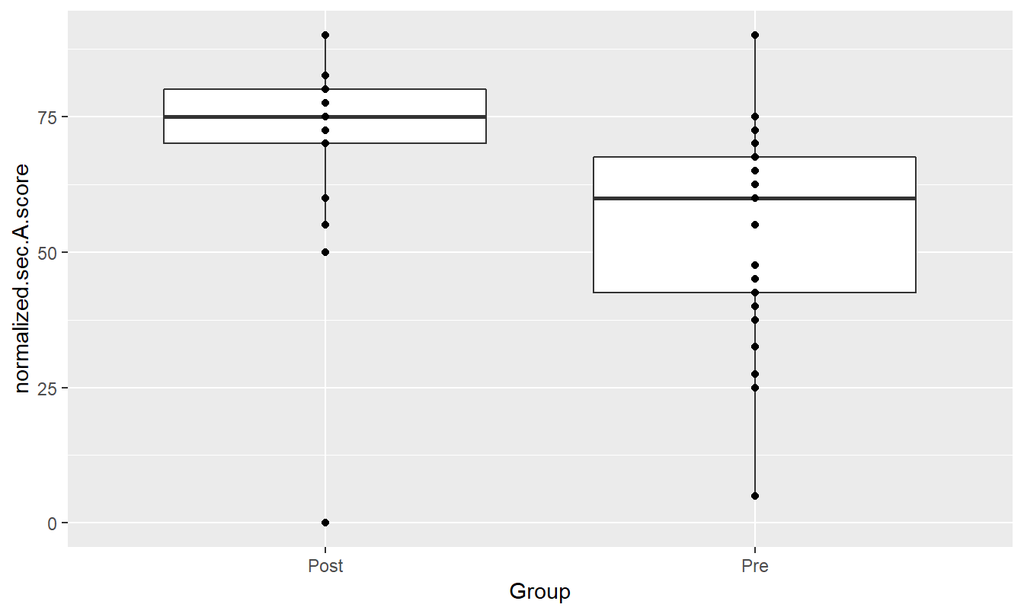

```r
p <- ggplot(heart.wide, aes(Group, normalized.sec.A.score))
p + geom_boxplot() + geom_point()
```

The box plot shows the distribution of the normalized scores between the two groups and it seems there is a significant difference between the scores.

Now, we can test whether the normalized score was different between the **pre** and **post** groups using a one-way ANOVA as follows:

```r
fit <- lm(normalized.sec.A.score ~ Group, data = heart.wide)
summary(fit)
```

```
Call:
lm(formula = normalized.sec.A.score ~ Group, data = heart.wide)

Residuals:
    Min      1Q  Median      3Q     Max
-71.083 -11.083   3.917  10.979  35.833

Coefficients:
            Estimate Std. Error t value Pr(>|t|)
(Intercept)   71.083      3.239  21.949  < 2e-16 ***
GroupPre     -16.917      4.580  -3.694 0.000491 ***
---
Signif. codes:  0 '***' 0.001 '**' 0.01 '*' 0.05 '.' 0.1 ' ' 1

Residual standard error: 17.74 on 58 degrees of freedom
Multiple R-squared:  0.1904,    Adjusted R-squared:  0.1765
F-statistic: 13.64 on 1 and 58 DF,  p-value: 0.0004912
```

**The P-value for the test of difference in mean normalized section A score between pre and post groups is 0.000491, which implies that there was a significant improvement of the test score in the post group.**

# 4 Next Steps

1. We will repeat this for section B and section C.
2. Which individual variables are important here? Exercise, Salt, Water, Forget Meds?
3. What other visualization do we need?